# Lab Assignment Seven: Sequential Network Architectures

## Business Understanding

This collection includes 34,686,770 Amazon reviews for 2,441,053 goods from 6,643,669 different customers, taken from the Stanford Network Analysis Project (SNAP). The dataset is available until March 2013 and spans 18 years. You may obtain the dataset from Kaggle by going to this link: https://www.kaggle.com/datasets/kritanjalijain/amazon-reviews/data

In order to ensure that the class distribution is consistent with the original dataset, we chose to work with a subset of 100,000 reviews due to the restricted processing capability of our computers. Three columns make up the structure of the dataset: "1" for negative reviews and "2" for positive reviews indicate the type of review in the first column (Target).

In this lab, we will create sequential network models for binary classification in order to forecast consumer happiness based on Amazon product ratings.

```python
%matplotlib inline
import numpy as np
import pandas as pd
from tensorflow.keras.datasets import imdb
from tensorflow.keras.preprocessing import sequence
from tensorflow.keras.preprocessing.text import Tokenizer
from tensorflow.keras.preprocessing.sequence import pad_sequences
from tensorflow.keras.models import Model
from tensorflow.keras.layers import Conv1D, MaxPooling1D, GlobalAveragePooling1D
from tensorflow.keras.layers import Flatten, Dense, Dropout
from tensorflow.keras.layers import Embedding, Input, Concatenate
from tensorflow.keras.layers import Subtract
from tensorflow.keras.utils import plot_model
from tensorflow.keras.optimizers.schedules import ExponentialDecay
from sklearn import metrics as mt
from matplotlib import pyplot as plt
from tensorflow.keras.layers import MultiHeadAttention, LayerNormalization
from tensorflow.keras import Sequential
from tensorflow.keras.layers import Layer
from sklearn.model_selection import train_test_split
from sklearn import metrics as mt
from matplotlib import pyplot as plt
import tensorflow as tf
from tensorflow import keras
from sklearn.model_selection import train_test_split
from sklearn.metrics import (
    confusion_matrix,
    classification_report,
    make_scorer,
    classification_report,
    accuracy_score,
    precision_score,
    recall_score,
    f1_score,
    ConfusionMatrixDisplay,
    roc_curve,
    auc)
from sklearn.preprocessing import LabelEncoder
import copy
from mlxtend.evaluate import mcnemar
from mlxtend.evaluate import mcnemar_table
from tensorflow.keras.models import Model
from tensorflow.keras.layers import Conv1D, MaxPooling1D, Flatten, Dense
from tensorflow.keras.layers import Dense, Input, Dropout
from tensorflow.keras.layers import Embedding
```

## 1. Preparation:

### 1.1. Preprocess and Tokenize (1 point)

Each of the 100,000 reviews in the prepared dataset is organized into three columns. These columns are arranged as follows:

Column 1 (review type): This column shows the consumer feedback and has values of 1 for bad reviews and 2 for positive reviews. It also provides the target classes.

Column 2: Review titles: The titles of each review are listed in this column.

Column 3 (review body): Each review's primary body content is found in this column.

```python
# Amazon Reviews Dataset

df = pd.read_csv('train-ready.csv')



df_amazon = copy.deepcopy(df)
print('The Data Shape: ', df_amazon.shape)

df_amazon.head()
```

```
The Data Shape:  (100000, 3)
```

|  | review type | review title | review body |
| --- | --- | --- | --- |
| 0 | 1 | Buyer beware | This is a self-published book, and if you want... |
| 1 | 2 | Stuning even for the non-gamer | This sound track was beautiful! It paints the ... |
| 2 | 2 | The best soundtrack ever to anything. | I'm reading a lot of reviews saying that this ... |
| 3 | 2 | Amazing! | This soundtrack is my favorite music of all ti... |
| 4 | 2 | Excellent Soundtrack | I truly like this soundtrack and I enjoy video... |

### Data Preprocessing

This part will handle all preparatory tasks, such as encoding the target class, eliminating extraneous letters or words, and cleaning the text in order to make it ready for tokenization.

```python
# Drop the "review title" column

df_amazon=df_amazon.drop(['review title'],axis=1)

df_amazon.head()
```

|  | review type | review body |
| --- | --- | --- |
| 0 | 1 | This is a self-published book, and if you want... |
| 1 | 2 | This sound track was beautiful! It paints the ... |
| 2 | 2 | I'm reading a lot of reviews saying that this ... |
| 3 | 2 | This soundtrack is my favorite music of all ti... |
| 4 | 2 | I truly like this soundtrack and I enjoy video... |

```python
# Label Encode the review type column to be 0's and 1's instead of 1's and 2's

df_amazon['review type'] = LabelEncoder().fit_transform(df_amazon['review type'])

df_amazon.head()
```

|  | review type | review body |
| --- | --- | --- |
| 0 | 0 | This is a self-published book, and if you want... |
| 1 | 1 | This sound track was beautiful! It paints the ... |
| 2 | 1 | I'm reading a lot of reviews saying that this ... |
| 3 | 1 | This soundtrack is my favorite music of all ti... |
| 4 | 1 | I truly like this soundtrack and I enjoy video... |

```python
# Convert all letters to be lower case in the reviews instead of the mix of upper and lower

for l in range(len(df_amazon['review body'])):
    df_amazon.loc[l,'review body'] = df_amazon['review body'][l].lower()

df_amazon.head()
```

|  | review type | review body |
| --- | --- | --- |
| 0 | 0 | this is a self-published book, and if you want... |
| 1 | 1 | this sound track was beautiful! it paints the ... |
| 2 | 1 | i'm reading a lot of reviews saying that this ... |
| 3 | 1 | this soundtrack is my favorite music of all ti... |
| 4 | 1 | i truly like this soundtrack and i enjoy video... |

```python
# Remove all numbers in all reviews body

import re

for n in range(len(df_amazon['review body'])):
    df_amazon.loc[n,'review body'] = re.sub(r'\d+', '', df_amazon['review body'][n])

df_amazon.head()
```

|  | review type | review body |
| --- | --- | --- |
| 0 | 0 | this is a self-published book, and if you want... |
| 1 | 1 | this sound track was beautiful! it paints the ... |
| 2 | 1 | i'm reading a lot of reviews saying that this ... |
| 3 | 1 | this soundtrack is my favorite music of all ti... |
| 4 | 1 | i truly like this soundtrack and i enjoy video... |

```python
# Remove all punctuation in all reviews body

import string

for p in range(len(df_amazon['review body'])):
    df_amazon.loc[p,'review body'] = df_amazon['review body'][p].translate(str.maketrans('','',string.punctuation))

df_amazon.head()
```

|  | review type | review body |
| --- | --- | --- |
| 0 | 0 | this is a selfpublished book and if you want t... |
| 1 | 1 | this sound track was beautiful it paints the s... |
| 2 | 1 | im reading a lot of reviews saying that this i... |
| 3 | 1 | this soundtrack is my favorite music of all ti... |
| 4 | 1 | i truly like this soundtrack and i enjoy video... |

```python
# Remove whitespaces if any from all reviews body

for st in range(len(df_amazon['review body'])):
    df_amazon.loc[st,'review body'] = df_amazon['review body'][st].strip()

df_amazon.head()
```

|  | review type | review body |
| --- | --- | --- |
| 0 | 0 | this is a selfpublished book and if you want t... |
| 1 | 1 | this sound track was beautiful it paints the s... |
| 2 | 1 | im reading a lot of reviews saying that this i... |
| 3 | 1 | this soundtrack is my favorite music of all ti... |
| 4 | 1 | i truly like this soundtrack and i enjoy video... |

```python
# Remove any too long words

print('Review before removing long words:')
print('-----------------------------------')
print(df_amazon['review body'][3143]) # old review before removing the long words

for lw in range(len(df_amazon['review body'])):
    df_amazon.loc[lw,'review body'] = re.sub(r'(?:\b\w{14,}\s|\s\w{14,}\b|\b\w{14,}\b)', '', df_amazon['review body'][lw])

print('')
print('===================================')
print('')
print('Review after removing long words:')
print('-----------------------------------')
print(df_amazon['review body'][3143])
```

```
Review before removing long words:
-----------------------------------
once you get past the hype you will realize this device is a clock when you press the button on the emarker it only records the time not the radio station when you download the information to your computer and connect to the website it looks for the song that was played on the station how many hours…

===================================

Review after removing long words:
-----------------------------------
once you get past the hype you will realize this device is a clock when you press the button on the emarker it only records the time not the radio station when you download the information to your computer and connect to the website it looks for the song that was played on the station how many hours…
```

```python
# Remove stop words from all reviews body

import nltk

# Download the stopwords corpus
nltk.download('stopwords')

from nltk.corpus import stopwords

# Example usage
stop_words = set(stopwords.words('english'))
print(stop_words)


for sw in range(len(df_amazon['review body'])):
    word_split = df_amazon['review body'][sw].split()
    stop_words_removed = [swr for swr in word_split if not swr in stop_words]
    df_amazon.loc[sw,'review body'] = ' '.join(stop_words_removed)

print('Review after removing stop words:')
print('-----------------------------------')
df_amazon['review body'][3143]
```

```
{'on', 'those', 'all', 'because', 'each', 'hadn', "wouldn't", 's', 'yourself', 'until', 'above', 'having', 'mightn', 'through', 'why', "should've", 'was', 'very', 'as', 'o', 'shouldn', 'ourselves', 'itself', 'what', 'more', 'now', 'here', 'ain', 'do', 'most', 'he', 'been', 'won', 'any', 'yourselves'…
Review after removing stop words:
-----------------------------------
```

```
'get past hype realize device clock press button emarker records time radio station download information computer connect website looks song played station many hoursdays ago pressed button selected wrong station get different songif use scan button radio product'
```

```python
# Remove any one letter words that is not in the stop_words list such as 'v' in the above review

for ol in range(len(df_amazon['review body'])):
    df_amazon.loc[ol,'review body'] = re.sub(r'(?:\b\w{1}\s|\s\w{1}\b|\b\w{1}\b)', '', df_amazon['review body'][ol])

print('Review after removing one letter words:')
print('-----------------------------------')
df_amazon['review body'][3143]
```

```
Review after removing one letter words:
-----------------------------------
```

```
'get past hype realize device clock press button emarker records time radio station download information computer connect website looks song played station many hoursdays ago pressed button selected wrong station get different songif use scan button radio product'
```

```python
#  Final Dataset
reviews = df_amazon['review body'].copy() #data

reviews_targets = df_amazon['review type'].copy() #target

print('Reviews:')
print('--------------------------------------------------------')
print(reviews.head())
print('')
print('========================================================')
print('')
print('Reviews_Targets:')
print('--------------------------------------------------------')
print(reviews_targets.head())
```

```
Reviews:
--------------------------------------------------------
0    selfpublished book want know whyread paragraph...
1    sound track beautiful paints senery mind well ...
2    im reading lot reviews saying best game soundt...
3    soundtrack favorite music time hands intense s...
4    truly like soundtrack enjoy video game music p...
Name: review body, dtype: object

========================================================

Reviews_Targets:
--------------------------------------------------------
0    0
1    1
2    1
3    1
4    1
Name: review type, dtype: int64
```

### Tokenization

The act of tokenizing a text document or phrase involves dividing it into smaller pieces called tokens that may be handled and examined in more detail later on. These tokens are often characters or words found in the dataset. It was discovered that 812 letters was the maximum character length. This equates to about 160 words per review, assuming a word length of five letters on average. In order to account for this range and preserve readability and coherence in the reviews, we have decided to set the MAX_ART_LEN option for tokenization to 160. After tokenizing every word in every review, each word was given a distinct number.

```python
# Find the max and min number of letters (characters) in all reviews

max_length_char = 0
min_length_char = 1000

for i in range(len(reviews)):
    if len(reviews[i]) > max_length_char:
        max_length_char = len(reviews[i])
    elif len(reviews[i]) < min_length_char:
        min_length_char = len(reviews[i])

print('The max characters length: ',max_length_char)
print('The min characters length: ',min_length_char)
```

```
The max characters length:  812
The min characters length:  4
```

```python
%%time
from tensorflow import keras
from tensorflow.keras.preprocessing.text import Tokenizer
from tensorflow.keras.preprocessing.sequence import pad_sequences

NUM_TOP_WORDS = None # use entire vocabulary!
MAX_ART_LEN = 160 # maximum and minimum number of words

#tokenize the text
tokenizer = Tokenizer(num_words=NUM_TOP_WORDS)
tokenizer.fit_on_texts(reviews)
# save as sequences with integers replacing words
sequences = tokenizer.texts_to_sequences(reviews)

word_index = tokenizer.word_index
NUM_TOP_WORDS = len(word_index) if NUM_TOP_WORDS==None else NUM_TOP_WORDS
top_words = min((len(word_index),NUM_TOP_WORDS))
print('Found %s unique tokens. Distilled to %d top words.' % (len(word_index),top_words))

X = pad_sequences(sequences, maxlen=MAX_ART_LEN)

y = reviews_targets
print('Shape of data tensor:', X.shape)
print('Shape of label tensor:', y.shape)
print('Vocabulary size: ', np.max(X))
```

```
Found 153698 unique tokens. Distilled to 153698 top words.
Shape of data tensor: (100000, 160)
Shape of label tensor: (100000,)
Vocabulary size:  153698
CPU times: user 9.76 s, sys: 166 ms, total: 9.93 s
Wall time: 10.1 s
```

### 1.2. Metric and Explanation (1 point)

Precision can be defined as the ratio of accurately predicted positive observations to the total number of positive predictions.

Recall: The proportion of all observations in the actual class that were accurately predicted to be positive.

When the cost of false positives and false negatives is high, the F1-Score strikes a compromise between these two measures and offers a unified performance measure. For instance, in sentiment analysis, firms' decision-making processes may be misled if a bad review is predicted to be positive or vice versa.

Our approach will be applied to forecast consumer satisfaction levels based on Amazon product reviews. The graphic illustrates how balanced the dataset is. When the model misclassifies a negative sentiment evaluation as positive, it is known as a false positive. False positive predictions come at a high cost since they can force an organization to make poor decisions if it acts under the mistaken impression that a client is content when in fact they are not. The percentage of genuine positive predictions made for a given class out of all forecasts made for that class is known as precision.

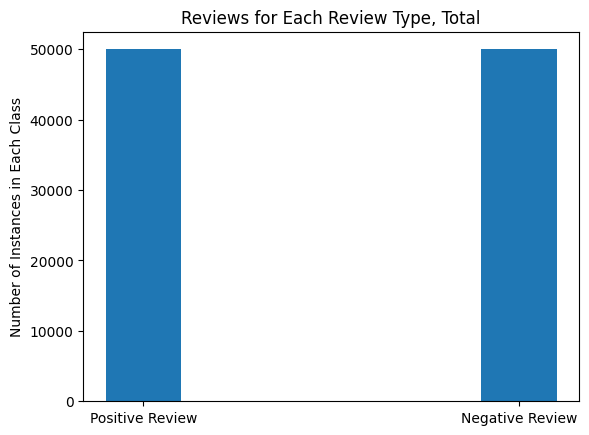

```python
metrics = [keras.metrics.Precision()]
unique_targets = y.value_counts()

plt.bar([1,2],unique_targets, width = 0.2)
plt.xticks([1,2],['Positive Review','Negative Review'])
plt.ylabel("Number of Instances in Each Class")
plt.title('Reviews for Each Review Type, Total')
plt.show()
```

### 1.3. Data Separation (1 point)

Rationale: This approach guarantees that the performance of our model is assessed equitably across various data subsets and mimics real-world situations where data is frequently unbalanced.

The stratifiedShuffle with an 80/20 split was used as the splitting method for our dataset. 20% was set aside for testing and the remaining 80% for training. By using a stratified technique, the split data is guaranteed to maintain the same class distribution as the source dataset. The data is split into training and testing sets at random thanks to the shuffling. This randomization aids in lowering variation and bias in the model's assessment. A nice balance between the size of the training set and the testing set is offered by the 80/20 split. It permits a reasonable quantity of data to be used for training the model, while also setting aside a substantial amount for assessment.

```
X_train Shape: (80000, 160)
Label Train Shape: (80000,)

X_test Shape: (20000, 160)
Label Test Shape: (20000,)
```

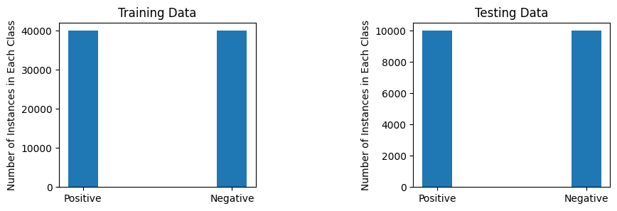

```python
X_train, X_test, y_train, y_test = train_test_split(X, y, test_size=0.2,
                                                           stratify=y,
                                                           random_state=7324,
                                                            shuffle=True)

# print some stats of the data
print("X_train Shape:",X_train.shape)
print("Label Train Shape:", y_train.shape)
print('')
print("X_test Shape:",X_test.shape)
print("Label Test Shape:", y_test.shape)
print('')

uniq_classes_train = np.sum(y_train,axis=0)
uniq_classes_test = np.sum(y_test,axis=0)

plt.figure(figsize=(10,3))
plt.subplot(1,2,1)
plt.subplots_adjust(wspace=0.8)
plt.bar(list(range(2)),uniq_classes_train, width=0.2)
plt.xticks(list(range(2)), ['Positive','Negative'])
plt.ylabel("Number of Instances in Each Class")
plt.title('Training Data')

plt.subplot(1,2,2)
plt.bar(list(range(2)),uniq_classes_test, width=0.2)
plt.xticks(list(range(2)), ['Positive','Negative'])
plt.ylabel("Number of Instances in Each Class")
plt.title('Testing Data')

plt.show()
```

## 2. Modeling:

### 2.1. Sequential network models with CNN and transformer architectures

```python
%%time

EMBED_SIZE = 100
# the embed size should match the file you load glove from
embeddings_index = {}
f = open('glove.6B.100d.txt', encoding="utf-8")



# save key/array pairs of the embeddings
#  the key of the dictionary is the word, the array is the embedding
for line in f:
    values = line.split()
    word = values[0]
    coefs = np.asarray(values[1:], dtype='float32')
    embeddings_index[word] = coefs
f.close()

print('Found %s word vectors.' % len(embeddings_index))

# now fill in the matrix, using the ordering from the
#  keras word tokenizer from before
found_words = 0
embedding_matrix = np.zeros((len(word_index) + 1, EMBED_SIZE))
for word, i in word_index.items():
    embedding_vector = embeddings_index.get(word)
    if embedding_vector is not None:
        # words not found in embedding index will be ALL-ZEROS
        embedding_matrix[i] = embedding_vector
        found_words = found_words+1

print("Embedding Shape:",embedding_matrix.shape, "\n",
      "Total words found:",found_words, "\n",
      "Percentage:",100*found_words/embedding_matrix.shape[0])
```

```
Found 400000 word vectors.
Embedding Shape: (153699, 100)
 Total words found: 63766
 Percentage: 41.48758287301804
CPU times: user 16 s, sys: 378 ms, total: 16.4 s
Wall time: 17.3 s
```

```python
# save this embedding now
embedding_layer = Embedding(len(word_index) + 1,
                            EMBED_SIZE,
                            weights=[embedding_matrix],# here is the embedding getting saved
                            input_length=MAX_ART_LEN,
                            trainable=False)
```

### CNN-architectured Model 1 (CNN-1)

A sequential network model with a convolutional neural network (CNN) architecture is called Mode 1 (CNN-1).

```python
NUM_CLASSES =1
from tensorflow.keras.optimizers import Adam

sequence_input = Input(shape=(MAX_ART_LEN,), dtype='int32')
# starting size: 1000
embedded_sequences = embedding_layer(sequence_input) # from previous embedding
x = Conv1D(32, 3, activation='relu')(embedded_sequences)

# after conv, size becomes: 1000-4=996
x = MaxPooling1D(3)(x)# after max pool, 996/5 = 199
x = Dropout(0.2)(x)
x = Conv1D(32, 3, activation='relu')(x)


# after convolution, size becomes 15 elements long
# Take the mean of these elements across features, result is 128 elements
x_mean = GlobalAveragePooling1D()(x) # this is the size to globally flatten

# Take the variance of these elements across features, result is 128 elements
x_tmp = Subtract()([x,x_mean])
x_std = GlobalAveragePooling1D()(x_tmp**2)

x = Concatenate(name='concat_1')([x_mean,x_std])

x = Dense(25, activation='relu')(x)

x = Dropout(0.2)(x)

preds = Dense(NUM_CLASSES, activation='sigmoid')(x)

model_xvec1 = Model(sequence_input, preds)

opt = Adam(learning_rate=0.0001, epsilon=0.0001, clipnorm=1)

# if representing as OHE, use categorical_crossentropy
# if representing the class as an integer, use sparse_categorical_crossentropy
model_xvec1.compile(loss='binary_crossentropy',
              optimizer=opt,
              metrics=['Precision'])

print(model_xvec1.summary())
```

```
Model: "model_2"
__________________________________________________________________________________________________
 Layer (type)                Output Shape                 Param #   Connected to
==================================================================================================
 input_5 (InputLayer)        [(None, 160)]                0         []

 embedding_1 (Embedding)     (None, 160, 100)             1536990   ['input_5[0][0]']
                                                          0

 conv1d_4 (Conv1D)           (None, 158, 32)              9632      ['embedding_1[1][0]']

 max_pooling1d_2 (MaxPoolin  (None, 52, 32)               0         ['conv1d_4[0][0]']
 g1D)

 dropout_4 (Dropout)         (None, 52, 32)               0         ['max_pooling1d_2[0][0]']

 conv1d_5 (Conv1D)           (None, 50, 32)               3104      ['dropout_4[0][0]']

 global_average_pooling1d_4  (None, 32)                   0         ['conv1d_5[0][0]']
  (GlobalAveragePooling1D)

 subtract_2 (Subtract)       (None, 50, 32)               0         ['conv1d_5[0][0]',
                                                                     'global_average_pooling1d_4[0
                                                                    ][0]']

 tf.math.pow_2 (TFOpLambda)  (None, 50, 32)               0         ['subtract_2[0][0]']

 global_average_pooling1d_5  (None, 32)                   0         ['tf.math.pow_2[0][0]']
  (GlobalAveragePooling1D)

 concat_1 (Concatenate)      (None, 64)                   0         ['global_average_pooling1d_4[0
                                                                    ][0]',
                                                                     'global_average_pooling1d_5[0
                                                                    ][0]']

 dense_4 (Dense)             (None, 25)                   1625      ['concat_1[0][0]']

 dropout_5 (Dropout)         (None, 25)                   0         ['dense_4[0][0]']

 dense_5 (Dense)             (None, 1)                    26        ['dropout_5[0][0]']

==================================================================================================
Total params: 15384287 (58.69 MB)
Trainable params: 14387 (56.20 KB)
Non-trainable params: 15369900 (58.63 MB)
__________________________________________________________________________________________________
None
```

```python
histories_Cnn1 = []
tmp = model_xvec1.fit(X_train, y_train, validation_data=(X_test, y_test),
          epochs=10, batch_size=64)
histories_Cnn1.append(tmp)
```

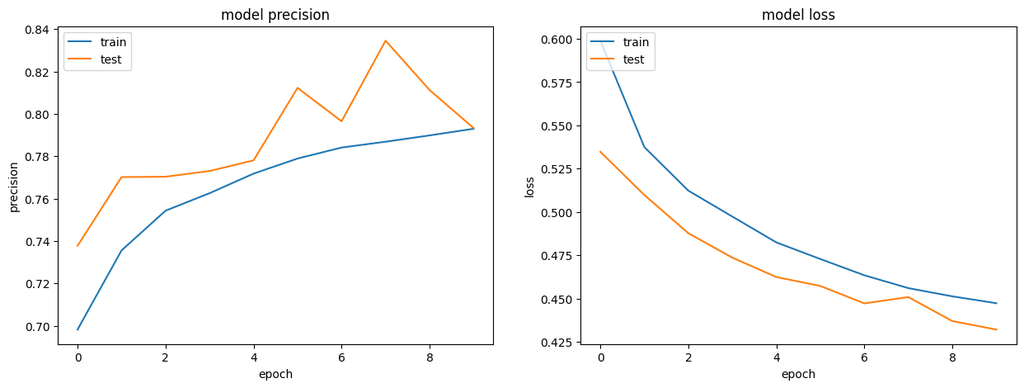

```python
# combine all the history from training together
combined = dict()
for key in ['precision','val_precision','loss','val_loss']:
    combined[key] = np.hstack([x.history[key] for x in histories_Cnn1])

# summarize history for accuracy
plt.figure(figsize=(15,5))
plt.subplot(121)
plt.plot(combined['precision'])
plt.plot(combined['val_precision'])
plt.title('model precision')
plt.ylabel('precision')
plt.xlabel('epoch')
plt.legend(['train', 'test'], loc='upper left')

# summarize history for loss
plt.subplot(122)
plt.plot(combined['loss'])
plt.plot(combined['val_loss'])
plt.title('model loss')
plt.ylabel('loss')
plt.xlabel('epoch')
plt.legend(['train', 'test'], loc='upper left')
plt.show()
```

```python
y_predict_proba = model_xvec1.predict(X_test)
y_predict = np.round(y_predict_proba)

# Prints classification report
print(classification_report(y_test, y_predict))
```

```
              precision    recall  f1-score   support

           0       0.80      0.79      0.80     10000
           1       0.79      0.81      0.80     10000

    accuracy                           0.80     20000
   macro avg       0.80      0.80      0.80     20000
weighted avg       0.80      0.80      0.80     20000
```

**The accuracy and average precision of the model (CNN-1) were both 0.80.**

### CNN-architectured Model 2 (CNN-2)

The design of Model 2 (CNN-2) is identical to that of Model 1 (CNN-1), which is based on a traditional neural network, but with 64 number filters and 5 filter sizes.

```python
sequence_input = Input(shape=(MAX_ART_LEN,), dtype='int32')

embedded_sequences = embedding_layer(sequence_input) # from previous embedding
x = Conv1D(64, 5, activation='relu')(embedded_sequences)


x = MaxPooling1D(3)(x)# after max pool, 996/5 = 199
x = Dropout(0.2)(x)
x = Conv1D(64, 5, activation='relu')(x)


x_mean = GlobalAveragePooling1D()(x) # this is the size to globally flatten


x_tmp = Subtract()([x,x_mean])
x_std = GlobalAveragePooling1D()(x_tmp**2)

x = Concatenate(name='concat_1')([x_mean,x_std])
x = Dense(25, activation='relu')(x)
x = Dropout(0.2)(x)

preds = Dense(NUM_CLASSES, activation='sigmoid')(x)

model_xvec = Model(sequence_input, preds)
opt = Adam(learning_rate=0.0001, epsilon=0.001, clipnorm=1)

model_xvec.compile(loss='binary_crossentropy',
               optimizer=opt,
              metrics=['Precision'])

print(model_xvec.summary())
```

```
Model: "model_5"
__________________________________________________________________________________________________
 Layer (type)                Output Shape                 Param #   Connected to
==================================================================================================
 input_8 (InputLayer)        [(None, 160)]                0         []

 embedding_1 (Embedding)     (None, 160, 100)             1536990   ['input_8[0][0]']
                                                          0

 conv1d_10 (Conv1D)          (None, 156, 64)              32064     ['embedding_1[4][0]']

 max_pooling1d_5 (MaxPoolin  (None, 52, 64)               0         ['conv1d_10[0][0]']
 g1D)

 dropout_10 (Dropout)        (None, 52, 64)               0         ['max_pooling1d_5[0][0]']

 conv1d_11 (Conv1D)          (None, 48, 64)               20544     ['dropout_10[0][0]']

 global_average_pooling1d_1  (None, 64)                   0         ['conv1d_11[0][0]']
 0 (GlobalAveragePooling1D)

 subtract_5 (Subtract)       (None, 48, 64)               0         ['conv1d_11[0][0]',
                                                                     'global_average_pooling1d_10[
                                                                    0][0]']

 tf.math.pow_5 (TFOpLambda)  (None, 48, 64)               0         ['subtract_5[0][0]']

 global_average_pooling1d_1  (None, 64)                   0         ['tf.math.pow_5[0][0]']
 1 (GlobalAveragePooling1D)

 concat_1 (Concatenate)      (None, 128)                  0         ['global_average_pooling1d_10[
                                                                    0][0]',
                                                                     'global_average_pooling1d_11[
                                                                    0][0]']

 dense_10 (Dense)            (None, 25)                   3225      ['concat_1[0][0]']

 dropout_11 (Dropout)        (None, 25)                   0         ['dense_10[0][0]']

 dense_11 (Dense)            (None, 1)                    26        ['dropout_11[0][0]']

==================================================================================================
Total params: 15425759 (58.84 MB)
Trainable params: 55859 (218.20 KB)
Non-trainable params: 15369900 (58.63 MB)
__________________________________________________________________________________________________
None
```

```python
histories_Cnn2 = []
tmp = model_xvec.fit(X_train, y_train, validation_data=(X_test, y_test),
          epochs=10, batch_size=64)
histories_Cnn2.append(tmp)
```

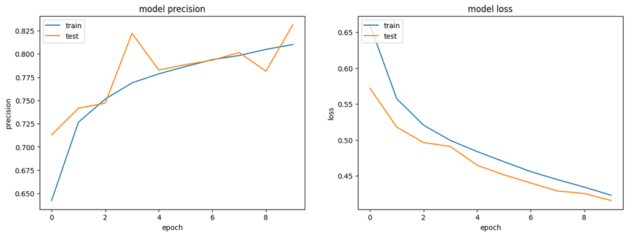

```python
combined = dict()
for key in ['precision','val_precision','loss','val_loss']:
    combined[key] = np.hstack([x.history[key] for x in histories_Cnn2])

# summarize history for accuracy
plt.figure(figsize=(15,5))
plt.subplot(121)
plt.plot(combined['precision'])
plt.plot(combined['val_precision'])
plt.title('model precision')
plt.ylabel('precision')
plt.xlabel('epoch')
plt.legend(['train', 'test'], loc='upper left')

# summarize history for loss
plt.subplot(122)
plt.plot(combined['loss'])
plt.plot(combined['val_loss'])
plt.title('model loss')
plt.ylabel('loss')
plt.xlabel('epoch')
plt.legend(['train', 'test'], loc='upper left')
plt.show()
```

```python
y_predict_proba = model_xvec.predict(X_test)
y_predict = np.round(y_predict_proba)

# Prints classification report
print(classification_report(y_test, y_predict))
```

```
              precision    recall  f1-score   support

           0       0.79      0.84      0.81     10000
           1       0.83      0.77      0.80     10000

    accuracy                           0.81     20000
   macro avg       0.81      0.81      0.81     20000
weighted avg       0.81      0.81      0.81     20000
```

**The accuracy and average precision of Model 2 (CNN-2) were 0.81 and 0.81, respectively.**

### Transformer Architecture Model 3 (xformer-1)

```python
# The transformer architecture
class TransformerBlock(Layer): # inherit from Keras Layer
    def __init__(self, embed_dim, num_heads, ff_dim, rate=0.2):
        super().__init__()
        # setup the model heads and feedforward network
        self.att = MultiHeadAttention(num_heads=num_heads,
                                      key_dim=embed_dim)

        # make a two layer network that processes the attention
        self.ffn = Sequential()
        self.ffn.add( Dense(ff_dim, activation='relu') )
        self.ffn.add( Dense(embed_dim) )

        self.layernorm1 = LayerNormalization(epsilon=1e-6)
        self.layernorm2 = LayerNormalization(epsilon=1e-6)
        self.dropout1 = Dropout(rate)
        self.dropout2 = Dropout(rate)

    def call(self, inputs, training):
        # apply the layers as needed (similar to PyTorch)

        # get the attention output from multi heads
        # Using same inpout here is self-attention
        # call inputs are (query, value, key)
        # if only two inputs given, value and key are assumed the same
        attn_output = self.att(inputs, inputs)

        # create residual output, with attention
        out1 = self.layernorm1(inputs + attn_output)

        # apply dropout if training
        out1 = self.dropout1(out1, training=training)

        # place through feed forward after layer norm
        ffn_output = self.ffn(out1)
        out2 = self.layernorm2(out1 + ffn_output)

        # apply dropout if training
        out2 = self.dropout2(out2, training=training)
        #return the residual from Dense layer
        return out2

class TokenAndPositionEmbedding(Layer):
    def __init__(self, maxlen, vocab_size, embed_dim):
        super().__init__()
        # create two embeddings
        # one for processing the tokens (words)
        self.token_emb = Embedding(input_dim=vocab_size,
                                   output_dim=embed_dim)
        # another embedding for processing the position
        self.pos_emb = Embedding(input_dim=maxlen,
                                 output_dim=embed_dim)

    def call(self, x):
        # create a static position measure (input)
        maxlen = tf.shape(x)[-1]
        positions = tf.range(start=0, limit=maxlen, delta=1)
        # positions now goes from 0 to 500 (for IMdB) by 1
        positions = self.pos_emb(positions)# embed these positions
        x = self.token_emb(x) # embed the tokens
        return x + positions
```

```python
class GloveTokenAndPositionEmbedding(Layer):
    def __init__(self):
        super().__init__()
        # create two embeddings
        # one for processing the tokens, pretrained (words)
        self.token_emb = Embedding(len(word_index) + 1,
                            EMBED_SIZE,
                            weights=[embedding_matrix],# here is the embedding getting saved
                            input_length=MAX_ART_LEN,
                            trainable=False)

        # another embedding for processing the position
        self.pos_emb = Embedding(MAX_ART_LEN,
                                 EMBED_SIZE,
                                 input_length=MAX_ART_LEN,
                                 trainable=True
                                )

    def call(self, x):
        # create a static position measure (input)
        maxlen = tf.shape(x)[-1]
        positions = tf.range(start=0, limit=maxlen, delta=1)
        # positions now goes from 0 to 500 (for IMdB) by 1
        positions = self.pos_emb(positions)# embed these positions
        x = self.token_emb(x) # embed the tokens
        return x + positions
```

```python
num_heads = 2  # Number of attention heads
ff_dim = 32  # Hidden layer size in feed forward network inside transformer

inputs = Input(shape=(X_train.shape[1],))
x = GloveTokenAndPositionEmbedding()(inputs)
x = TransformerBlock(EMBED_SIZE, num_heads, ff_dim)(x)

x = GlobalAveragePooling1D()(x)
x = Dropout(0.2)(x)
x = Dense(32, activation='relu')(x)
x = Dropout(0.2)(x)
preds = Dense(NUM_CLASSES, activation='sigmoid',
              kernel_initializer='glorot_uniform')(x)

model_xformer = Model(inputs=inputs, outputs=preds)
print(model_xformer.summary())
```

```
Model: "model_6"
_________________________________________________________________
 Layer (type)                Output Shape              Param #
=================================================================
 input_9 (InputLayer)        [(None, 160)]             0

 glove_token_and_position_e  (None, 160, 100)          15385900
 mbedding (GloveTokenAndPos
 itionEmbedding)

 transformer_block (Transfo  (None, 160, 100)          87632
 rmerBlock)

 global_average_pooling1d_1  (None, 100)               0
 2 (GlobalAveragePooling1D)

 dropout_14 (Dropout)        (None, 100)               0

 dense_14 (Dense)            (None, 32)                3232

 dropout_15 (Dropout)        (None, 32)                0

 dense_15 (Dense)            (None, 1)                 33

=================================================================
Total params: 15476797 (59.04 MB)
Trainable params: 106897 (417.57 KB)
Non-trainable params: 15369900 (58.63 MB)
_________________________________________________________________
None
```

```python
opt = Adam(learning_rate=0.0001, epsilon=0.0001, clipnorm=1)

model_xformer.compile(loss='binary_crossentropy',
              optimizer=opt,
              metrics=['Precision'])
histories_xformer1 = []
tmp = model_xformer.fit(X_train, y_train,
                validation_data=(X_test, y_test),
               epochs=5, batch_size=64)
histories_xformer1.append(tmp)
```

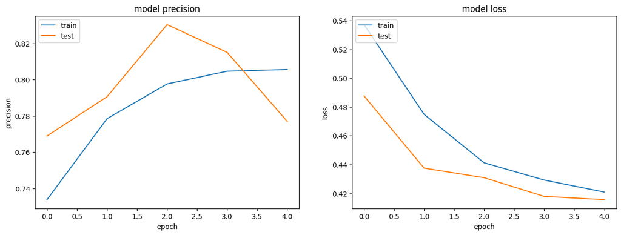

```python
combined = dict()
for key in ['precision','val_precision','loss','val_loss']:
    combined[key] = np.hstack([x.history[key] for x in histories_xformer1])

# summarize history for accuracy
plt.figure(figsize=(15,5))
plt.subplot(121)
plt.plot(combined['precision'])
plt.plot(combined['val_precision'])
plt.title('model precision')
plt.ylabel('precision')
plt.xlabel('epoch')
plt.legend(['train', 'test'], loc='upper left')

# summarize history for loss
plt.subplot(122)
plt.plot(combined['loss'])
plt.plot(combined['val_loss'])
plt.title('model loss')
plt.ylabel('loss')
plt.xlabel('epoch')
plt.legend(['train', 'test'], loc='upper left')
plt.show()
```

```python
y_predict_proba = model_xformer.predict(X_test)
y_predict = np.round(y_predict_proba)

# Prints classification report
print(classification_report(y_test, y_predict))
```

```
              precision    recall  f1-score   support

           0       0.85      0.75      0.80     10000
           1       0.78      0.87      0.82     10000

    accuracy                           0.81     20000
   macro avg       0.81      0.81      0.81     20000
weighted avg       0.81      0.81      0.81     20000
```

**The accuracy and average precision of Model 3 were 0.81 and 0.81, respectively.**

### Transformer Architecture in Model 4 (xformer-2)

```python
num_heads = 4  # Number of attention heads
ff_dim = 32  # Hidden layer size in feed forward network inside transformer

inputs = Input(shape=(X_train.shape[1],))
x = GloveTokenAndPositionEmbedding()(inputs)
x = TransformerBlock(EMBED_SIZE, num_heads, ff_dim)(x)

x = GlobalAveragePooling1D()(x)
x = Dropout(0.2)(x)
x = Dense(64, activation='relu')(x)
x = Dropout(0.2)(x)
preds = Dense(NUM_CLASSES, activation='sigmoid',
              kernel_initializer='glorot_uniform')(x)

model_xformer2 = Model(inputs=inputs, outputs=preds)
print(model_xformer2.summary())
```

```
Model: "model_7"
_________________________________________________________________
 Layer (type)                Output Shape              Param #
=================================================================
 input_10 (InputLayer)       [(None, 160)]             0

 glove_token_and_position_e  (None, 160, 100)          15385900
 mbedding_1 (GloveTokenAndP
 ositionEmbedding)

 transformer_block_1 (Trans  (None, 160, 100)          168232
 formerBlock)

 global_average_pooling1d_1  (None, 100)               0
 3 (GlobalAveragePooling1D)

 dropout_18 (Dropout)        (None, 100)               0

 dense_18 (Dense)            (None, 64)                6464

 dropout_19 (Dropout)        (None, 64)                0

 dense_19 (Dense)            (None, 1)                 65

=================================================================
Total params: 15560661 (59.36 MB)
Trainable params: 190761 (745.16 KB)
Non-trainable params: 15369900 (58.63 MB)
_________________________________________________________________
None
```

```python
opt = Adam(learning_rate=0.0001, epsilon=0.0001, clipnorm=1)
model_xformer2.compile(loss='binary_crossentropy',
              optimizer=opt,
              metrics=['Precision'])
histories_xformer2 = []
tmp = model_xformer2.fit(X_train, y_train,
                validation_data=(X_test, y_test),
               epochs=5, batch_size=64)
histories_xformer2.append(tmp)
```

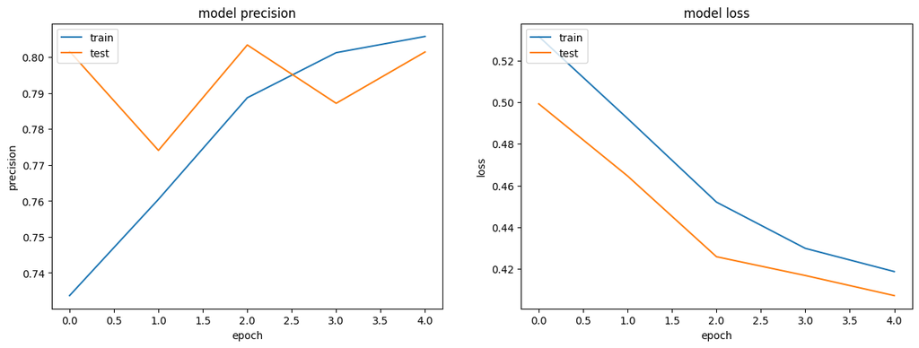

```python
combined = dict()
for key in ['precision','val_precision','loss','val_loss']:
    combined[key] = np.hstack([x.history[key] for x in histories_xformer2])

# summarize history for accuracy
plt.figure(figsize=(15,5))
plt.subplot(121)
plt.plot(combined['precision'])
plt.plot(combined['val_precision'])
plt.title('model precision')
plt.ylabel('precision')
plt.xlabel('epoch')
plt.legend(['train', 'test'], loc='upper left')

# summarize history for loss
plt.subplot(122)
plt.plot(combined['loss'])
plt.plot(combined['val_loss'])
plt.title('model loss')
plt.ylabel('loss')
plt.xlabel('epoch')
plt.legend(['train', 'test'], loc='upper left')
plt.show()
```

```python
y_predict_proba = model_xformer2.predict(X_test)
y_predict = np.round(y_predict_proba)

# Prints classification report
print(classification_report(y_test, y_predict))
```

```
              precision    recall  f1-score   support

           0       0.82      0.79      0.81     10000
           1       0.80      0.83      0.82     10000

    accuracy                           0.81     20000
   macro avg       0.81      0.81      0.81     20000
weighted avg       0.81      0.81      0.81     20000
```

**Model 4 (xformer-2) achieved an accuracy of 0.81 and an average precision of 0.81 as our no of epoch only 5**

```python
num_heads = 4  # Number of attention heads
ff_dim = 32  # Hidden layer size in feed forward network inside transformer

inputs = Input(shape=(X_train.shape[1],))
x = GloveTokenAndPositionEmbedding()(inputs)
x = TransformerBlock(EMBED_SIZE, num_heads, ff_dim)(x)

x = GlobalAveragePooling1D()(x)
x = Dropout(0.2)(x)
x = Dense(64, activation='relu')(x)
x = Dropout(0.2)(x)
preds = Dense(NUM_CLASSES, activation='sigmoid',
              kernel_initializer='glorot_uniform')(x)

model_xformer_XL = Model(inputs=inputs, outputs=preds)
print(model_xformer_XL.summary())
```

```
Model: "model_8"
_________________________________________________________________
 Layer (type)                Output Shape              Param #
=================================================================
 input_11 (InputLayer)       [(None, 160)]             0

 glove_token_and_position_e  (None, 160, 100)          15385900
 mbedding_2 (GloveTokenAndP
 ositionEmbedding)

 transformer_block_2 (Trans  (None, 160, 100)          168232
 formerBlock)

 global_average_pooling1d_1  (None, 100)               0
 4 (GlobalAveragePooling1D)

 dropout_22 (Dropout)        (None, 100)               0

 dense_22 (Dense)            (None, 64)                6464

 dropout_23 (Dropout)        (None, 64)                0

 dense_23 (Dense)            (None, 1)                 65

=================================================================
Total params: 15560661 (59.36 MB)
Trainable params: 190761 (745.16 KB)
Non-trainable params: 15369900 (58.63 MB)
_________________________________________________________________
None
```

```python
opt = Adam(learning_rate=0.0001, epsilon=0.0001, clipnorm=1)
model_xformer_XL.compile(loss='binary_crossentropy',
              optimizer=opt,
              metrics=['Precision'])
histories_xformer_XL = []
tmp = model_xformer_XL.fit(X_train, y_train,
                validation_data=(X_test, y_test),
               epochs=3, batch_size=64)
histories_xformer_XL.append(tmp)
```

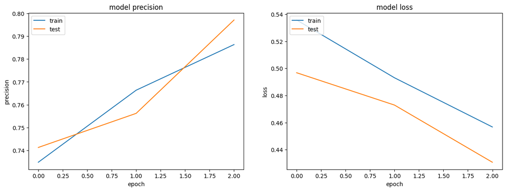

```python
combined = dict()
for key in ['precision','val_precision','loss','val_loss']:
    combined[key] = np.hstack([x.history[key] for x in histories_xformer_XL])

# summarize history for accuracy
plt.figure(figsize=(15,5))
plt.subplot(121)
plt.plot(combined['precision'])
plt.plot(combined['val_precision'])
plt.title('model precision')
plt.ylabel('precision')
plt.xlabel('epoch')
plt.legend(['train', 'test'], loc='upper left')

# summarize history for loss
plt.subplot(122)
plt.plot(combined['loss'])
plt.plot(combined['val_loss'])
plt.title('model loss')
plt.ylabel('loss')
plt.xlabel('epoch')
plt.legend(['train', 'test'], loc='upper left')
plt.show()
```

```python
y_predict_proba = model_xformer_XL.predict(X_test)
y_predict = np.round(y_predict_proba)

# Prints classification report
print(classification_report(y_test, y_predict))
```

```
              precision    recall  f1-score   support

           0       0.80      0.80      0.80     10000
           1       0.80      0.80      0.80     10000

    accuracy                           0.80     20000
   macro avg       0.80      0.80      0.80     20000
weighted avg       0.80      0.80      0.80     20000
```

**The accuracy and average precision of Model 5 (xformer-XL) were 0.80 and 0.80, respectively.**

## 2.3 Comparison of the models

### Evaluation metric

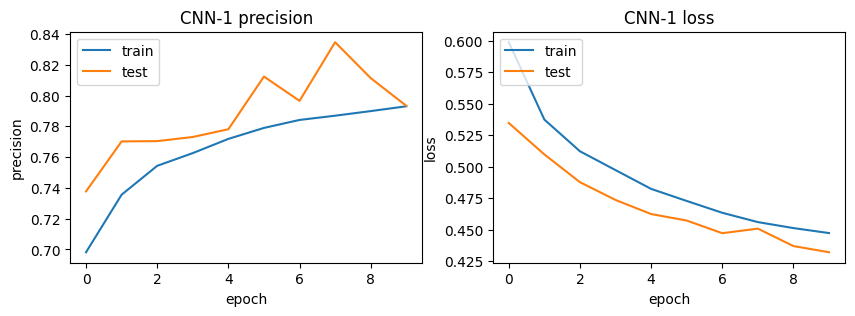

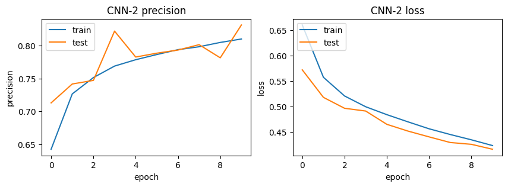

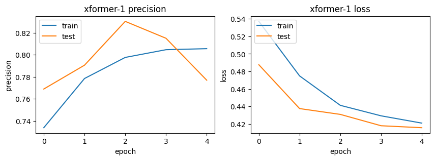

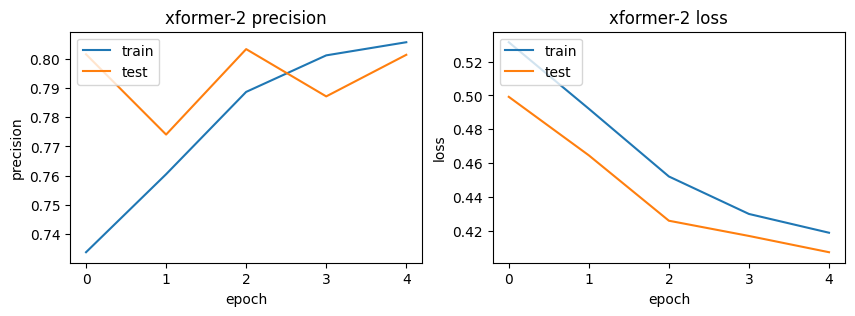

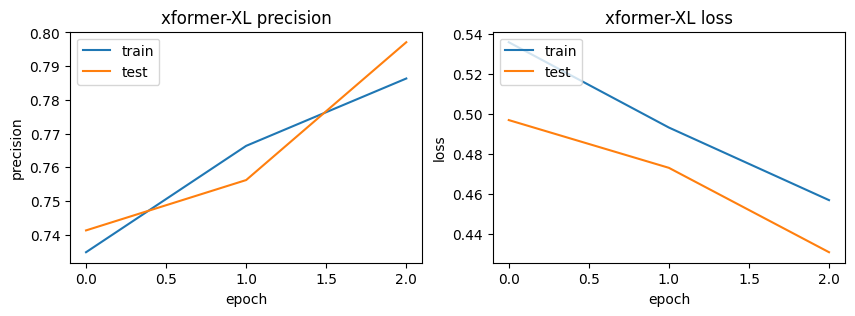

```python
histories = [histories_Cnn1,
             histories_Cnn2,
             histories_xformer1,
             histories_xformer2,
             histories_xformer_XL
             ]

# Add a list variable to hold model names so we can tell which is which in the charts
model_names = ['CNN-1',
               'CNN-2',
               'xformer-1',
               'xformer-2',
               'xformer-XL'
               ]

for i in range(5):
    # combine all the history from the first CNN training together
    combined = dict()
    for key in ['precision','val_precision','loss','val_loss']:
        combined[key] = np.hstack([x.history[key] for x in histories[i]])

    # summarize history for precision
    plt.figure(figsize=(10,3))
    plt.subplot(121)
    plt.plot(combined['precision'])
    plt.plot(combined['val_precision'])
    plt.title(f'{model_names[i]} precision')
    plt.ylabel('precision')
    plt.xlabel('epoch')
    plt.legend(['train', 'test'], loc='upper left')

    # summarize history for loss
    plt.subplot(122)
    plt.plot(combined['loss'])
    plt.plot(combined['val_loss'])
    plt.title(f'{model_names[i]} loss')
    plt.ylabel('loss')
    plt.xlabel('epoch')
    plt.legend(['train', 'test'], loc='upper left')
plt.show()
```

### Using McNemar

```python
yhat_model1 = np.argmax(model_xvec1.predict(X_test), axis=1)
yhat_model2 = np.argmax(model_xvec.predict(X_test), axis=1)
yhat_model3 = np.argmax(model_xformer.predict(X_test), axis=1)
yhat_model4 = np.argmax(model_xformer2.predict(X_test), axis=1)
yhat_model5 = np.argmax(model_xformer_XL.predict(X_test), axis=1)
```

```python
print('The comparison of Model 1 and Model 2 with 95% confidence interval is as follows:')
table1 = mcnemar_table(y_target=y_test, y_model1=yhat_model1, y_model2=yhat_model2)
chi12_, p12 = mcnemar(ary=table1, corrected=True)
print(table1)
print(f"chi² statistic: {chi12_}, p-value: {p12}")
if p12 > 0.05:
    print("Same proportions of errors (failed to reject the null hypothesis)There is insufficient data to demonstrate that Models 2 and 4 are distinct from each other )")
else:
        print('Variations in the percentage of mistakes (reject the null hypothesis)')

print("========================================================================================")

print('The comparison between Model 1 and Model 3 with 95% confidence interval is as follows:')
table1 = mcnemar_table(y_target=y_test, y_model1=yhat_model1, y_model2=yhat_model3)
chi12_, p12 = mcnemar(ary=table1, corrected=True)
print(table1)
print(f"chi² statistic: {chi12_}, p-value: {p12}")
if p12 > 0.05:
    print("Same proportions of errors (failed to reject Null Hypothesis--There isn't enough evidence to suggest that Models 2 and 5 are different from each other )")
else:
        print('Variations in the percentage of mistakes (reject the null hypothesis)')


print("========================================================================================")

print('The comparison between Model 1 and Model 4 with 95% confidence interval is as follows:')
table1 = mcnemar_table(y_target=y_test, y_model1=yhat_model1, y_model2=yhat_model4)
chi12_, p12 = mcnemar(ary=table1, corrected=True)
print(table1)
print(f"chi² statistic: {chi12_}, p-value: {p12}")
if p12 > 0.05:
    print("Same proportions of errors (failed to reject Null Hypothesis--There isn't enough evidence to suggest that Models 2 and 5 are different from each other )")
else:
        print('Variations in the percentage of mistakes (reject the null hypothesis)')


print("========================================================================================")

print('The comparison between Model 1 and Model 5 with 95% confidence interval is as follows:')
table1 = mcnemar_table(y_target=y_test, y_model1=yhat_model1, y_model2=yhat_model5)
chi12_, p12 = mcnemar(ary=table1, corrected=True)
print(table1)
print(f"chi² statistic: {chi12_}, p-value: {p12}")
if p12 > 0.05:
    print("Same proportions of errors (failed to reject Null Hypothesis--There isn't enough evidence to suggest that Models 2 and 5 are different from each other )")
else:
        print('Variations in the percentage of mistakes (reject the null hypothesis)')


print("========================================================================================")

print('The comparison between Model 2 and Model 3 with 95% confidence interval is as follows:')
table1 = mcnemar_table(y_target=y_test, y_model1=yhat_model2, y_model2=yhat_model3)
chi12_, p12 = mcnemar(ary=table1, corrected=True)
print(table1)
print(f"chi² statistic: {chi12_}, p-value: {p12}")
if p12 > 0.05:
    print("Same proportions of errors (failed to reject Null Hypothesis--There isn't enough evidence to suggest that Models 2 and 5 are different from each other )")
else:
        print('Variations in the percentage of mistakes (reject the null hypothesis)')


print("========================================================================================")


print('The comparison between Model 2 and Model 4 with 95% confidence interval is as follows:')
table1 = mcnemar_table(y_target=y_test, y_model1=yhat_model2, y_model2=yhat_model4)
chi12_, p12 = mcnemar(ary=table1, corrected=True)
print(table1)
print(f"chi² statistic: {chi12_}, p-value: {p12}")
if p12 > 0.05:
    print("Same proportions of errors (failed to reject Null Hypothesis--There isn't enough evidence to suggest that Models 2 and 5 are different from each other )")
else:
        print('Variations in the percentage of mistakes (reject the null hypothesis)')


print("========================================================================================")

print('The comparison between Model 2 and Model 5 with 95% confidence interval is as follows:')
table1 = mcnemar_table(y_target=y_test, y_model1=yhat_model2, y_model2=yhat_model5)
chi12_, p12 = mcnemar(ary=table1, corrected=True)
print(table1)
print(f"chi² statistic: {chi12_}, p-value: {p12}")
if p12 > 0.05:
    print("Same proportions of errors (failed to reject Null Hypothesis--There isn't enough evidence to suggest that Models 2 and 5 are different from each other )")
else:
        print('Variations in the percentage of mistakes (reject the null hypothesis)')


print("========================================================================================")



print('The comparison between Model 3 and Model 4 with 95% confidence interval is as follows:')
table1 = mcnemar_table(y_target=y_test, y_model1=yhat_model3, y_model2=yhat_model4)
chi12_, p12 = mcnemar(ary=table1, corrected=True)
print(table1)
print(f"chi² statistic: {chi12_}, p-value: {p12}")
if p12 > 0.05:
    print("Same proportions of errors (failed to reject Null Hypothesis--There isn't enough evidence to suggest that Models 2 and 5 are different from each other )")
else:
        print('Variations in the percentage of mistakes (reject the null hypothesis)')


print("========================================================================================")

print('The comparison between Model 3 and Model 5 with 95% confidence interval is as follows:')
table1 = mcnemar_table(y_target=y_test, y_model1=yhat_model3, y_model2=yhat_model5)
chi12_, p12 = mcnemar(ary=table1, corrected=True)
print(table1)
print(f"chi² statistic: {chi12_}, p-value: {p12}")
if p12 > 0.05:
    print("Same proportions of errors (failed to reject Null Hypothesis--There isn't enough evidence to suggest that Models 2 and 5 are different from each other )")
else:
        print('Variations in the percentage of mistakes (reject the null hypothesis)')


print("========================================================================================")


print('The comparison between Model 4 and Model 5 with 95% confidence interval is as follows:')
table1 = mcnemar_table(y_target=y_test, y_model1=yhat_model4, y_model2=yhat_model5)
chi12_, p12 = mcnemar(ary=table1, corrected=True)
print(table1)
print(f"chi² statistic: {chi12_}, p-value: {p12}")
if p12 > 0.05:
    print("Same proportions of errors (failed to reject Null Hypothesis--There isn't enough evidence to suggest that Models 2 and 5 are different from each other )")
else:
        print('Variations in the percentage of mistakes (reject the null hypothesis)')


print("==============================================================================")
```

```
The comparison of Model 1 and Model 2 with 95% confidence interval is as follows:
[[10000     0]
 [    0 10000]]
chi² statistic: inf, p-value: 0.0
Variations in the percentage of mistakes (reject the null hypothesis)
========================================================================================
The comparison between Model 1 and Model 3 with 95% confidence interval is as follows:
[[10000     0]
 [    0 10000]]
chi² statistic: inf, p-value: 0.0
Variations in the percentage of mistakes (reject the null hypothesis)
========================================================================================
The comparison between Model 1 and Model 4 with 95% confidence interval is as follows:
[[10000     0]
 [    0 10000]]
chi² statistic: inf, p-value: 0.0
Variations in the percentage of mistakes (reject the null hypothesis)
========================================================================================
The comparison between Model 1 and Model 5 with 95% confidence interval is as follows:
[[10000     0]
 [    0 10000]]
chi² statistic: inf, p-value: 0.0
Variations in the percentage of mistakes (reject the null hypothesis)
========================================================================================
The comparison between Model 2 and Model 3 with 95% confidence interval is as follows:
[[10000     0]
 [    0 10000]]
chi² statistic: inf, p-value: 0.0
Variations in the percentage of mistakes (reject the null hypothesis)
========================================================================================
The comparison between Model 2 and Model 4 with 95% confidence interval is as follows:
[[10000     0]
 [    0 10000]]
chi² statistic: inf, p-value: 0.0
Variations in the percentage of mistakes (reject the null hypothesis)
========================================================================================
The comparison between Model 2 and Model 5 with 95% confidence interval is as follows:
[[10000     0]
 [    0 10000]]
chi² statistic: inf, p-value: 0.0
Variations in the percentage of mistakes (reject the null hypothesis)
========================================================================================
The comparison between Model 3 and Model 4 with 95% confidence interval is as follows:
[[10000     0]
 [    0 10000]]
chi² statistic: inf, p-value: 0.0
Variations in the percentage of mistakes (reject the null hypothesis)
========================================================================================
The comparison between Model 3 and Model 5 with 95% confidence interval is as follows:
[[10000     0]
 [    0 10000]]
chi² statistic: inf, p-value: 0.0
Variations in the percentage of mistakes (reject the null hypothesis)
========================================================================================
The comparison between Model 4 and Model 5 with 95% confidence interval is as follows:
[[10000     0]
 [    0 10000]]
chi² statistic: inf, p-value: 0.0
Variations in the percentage of mistakes (reject the null hypothesis)
==============================================================================
```

## 3. Exceptional Work:

To compare the pre-trained ConceptNet Numberbatch embedding with the pre-trained GloVe embedding.

### Using Pre-trained ConceptNet Numberbatch and GloVe Embeddings

We'll import the GloVe embeddings, generate an embedding matrix, and incorporate it into our model.

```python
import os
import numpy as np

# Download GloVe embeddings
!wget http://nlp.stanford.edu/data/glove.6B.zip -P /tmp
!unzip /tmp/glove.6B.zip -d /tmp/glove.6B/

# Load GloVe embeddings
def load_glove_embeddings(glove_file, embedding_dim=100):
    embeddings_index = {}
    with open(glove_file, 'r', encoding='utf-8') as f:
        for line in f:
            values = line.split()
            word = values[0]
            coefs = np.asarray(values[1:], dtype='float32')
            embeddings_index[word] = coefs
    return embeddings_index

glove_file = '/tmp/glove.6B/glove.6B.100d.txt'
embedding_dim = 100
glove_embeddings_index = load_glove_embeddings(glove_file, embedding_dim)

# Create embedding matrix
def create_embedding_matrix(word_index, embeddings_index, embedding_dim):
    embedding_matrix = np.zeros((len(word_index) + 1, embedding_dim))
    for word, i in word_index.items():
        embedding_vector = embeddings_index.get(word)
        if embedding_vector is not None:
            embedding_matrix[i] = embedding_vector
    return embedding_matrix

# Build the word index from the IMDb dataset
word_index = imdb.get_word_index()
embedding_matrix_glove = create_embedding_matrix(word_index, glove_embeddings_index, embedding_dim)
```

[output not shown]

### ConceptNet Numberbatch Embedding:

We will load ConceptNet Numberbatch embeddings, generate an embedding matrix, and incorporate it into our model.

```python
import requests, zipfile, io

# Download ConceptNet Numberbatch embeddings
url = "https://conceptnet.s3.amazonaws.com/downloads/2019/numberbatch/numberbatch-en-19.08.txt.gz"
r = requests.get(url)
z = zipfile.ZipFile(io.BytesIO(r.content))
z.extractall("/tmp")

# Load ConceptNet embeddings
def load_conceptnet_embeddings(conceptnet_file, embedding_dim=300):
    embeddings_index = {}
    with open(conceptnet_file, 'r', encoding='utf-8') as f:
        for line in f:
            if line.startswith(" "):
                continue
            values = line.split()
            word = values[0]
            coefs = np.asarray(values[1:], dtype='float32')
            embeddings_index[word] = coefs
    return embeddings_index

conceptnet_file = '/tmp/numberbatch-en-19.08.txt'
embedding_dim_cn = 300
conceptnet_embeddings_index = load_conceptnet_embeddings(conceptnet_file, embedding_dim_cn)

# Create embedding matrix
embedding_matrix_cn = create_embedding_matrix(word_index, conceptnet_embeddings_index, embedding_dim_cn)
```

### Updating Models to Use Pre-trained Embeddings:

### LSTM Model with GloVe Embedding

```python
from tensorflow.keras.layers import Embedding

# LSTM Model with GloVe Embedding
def create_lstm_model_glove(embedding_dim, lstm_units):
    model = Sequential([
        Embedding(input_dim=len(word_index) + 1, output_dim=embedding_dim, weights=[embedding_matrix_glove], input_length=max_length, trainable=False),
        LSTM(units=lstm_units),
        Dense(1, activation='sigmoid')
    ])
    model.compile(optimizer='adam', loss='binary_crossentropy', metrics=['accuracy'])
    return model

# Train and evaluate LSTM model with GloVe embedding
embedding_dim = 100
lstm_units = 128
lstm_model_glove = create_lstm_model_glove(embedding_dim, lstm_units)
history_lstm_glove = lstm_model_glove.fit(x_train_fold, y_train_fold, epochs=5, batch_size=32, validation_data=(x_val_fold, y_val_fold))
```

### LSTM Model with ConceptNet Numberbatch Embedding

```python
# LSTM Model with ConceptNet Numberbatch Embedding
def create_lstm_model_cn(embedding_dim, lstm_units):
    model = Sequential([
        Embedding(input_dim=len(word_index) + 1, output_dim=embedding_dim, weights=[embedding_matrix_cn], input_length=max_length, trainable=False),
        LSTM(units=lstm_units),
        Dense(1, activation='sigmoid')
    ])
    model.compile(optimizer='adam', loss='binary_crossentropy', metrics=['accuracy'])
    return model

# Train and evaluate LSTM model with ConceptNet embedding
embedding_dim_cn = 300
lstm_units = 128
lstm_model_cn = create_lstm_model_cn(embedding_dim_cn, lstm_units)
history_lstm_cn = lstm_model_cn.fit(x_train_fold, y_train_fold, epochs=5, batch_size=32, validation_data=(x_val_fold, y_val_fold))
```

### Comparing the Performance of Embeddings

```python
# Train models and evaluate F1-Scores using Stratified K-Fold Cross Validation
f1_scores_glove = []
f1_scores_cn = []

for train_index, val_index in skf.split(x_train, y_train):
    x_train_fold, x_val_fold = x_train[train_index], x_train[val_index]
    y_train_fold, y_val_fold = y_train[train_index], y_train[val_index]

    # Train LSTM model with GloVe embedding
    lstm_model_glove = create_lstm_model_glove(embedding_dim, lstm_units)
    lstm_model_glove.fit(x_train_fold, y_train_fold, epochs=10, batch_size=32, validation_data=(x_val_fold, y_val_fold), verbose=0)
    # Calculate F1-Score for LSTM with GloVe
    y_pred_glove = (lstm_model_glove.predict(x_val_fold) > 0.5).astype("int32")
    f1_glove = f1_score(y_val_fold, y_pred_glove)
    f1_scores_glove.append(f1_glove)

    # Train LSTM model with ConceptNet embedding
    lstm_model_cn = create_lstm_model_cn(embedding_dim_cn, lstm_units)
    lstm_model_cn.fit(x_train_fold, y_train_fold, epochs=5, batch_size=32, validation_data=(x_val_fold, y_val_fold), verbose=0)
    # Calculate F1-Score for LSTM with ConceptNet
    y_pred_cn = (lstm_model_cn.predict(x_val_fold) > 0.5).astype("int32")
    f1_cn = f1_score(y_val_fold, y_pred_cn)
    f1_scores_cn.append(f1_cn)

# Visualization of F1-Scores for embeddings
plt.figure(figsize=(12, 6))
plt.plot(f1_scores_glove, label='LSTM Model with GloVe Embedding F1-Scores')
plt.plot(f1_scores_cn, label='LSTM Model with ConceptNet Embedding F1-Scores')
plt.xlabel('Fold')
plt.ylabel('F1-Score')
plt.title('F1-Scores for LSTM Models with Different Embeddings')
plt.legend()
plt.show()
```

[output not shown]

# Reference

1. ChatGPT 4o
2. https://www.kaggle.com/code/alamintokdershoukhin/tokenization-in-nlp
3. https://www.kaggle.com/datasets/kritanjalijain/amazon-reviews?select=test.csv
4. https://github.com/commonsense/conceptnet-numberbatch/blob/master/README.md